# BTS 510 Lab 4

```r
set.seed(12345)
library(tidyverse)
library(Stat2Data)
theme_set(theme_classic(base_size = 16))
cbCSPalette <- c("#76777a", "#3697aa", "#dc1e34", "#009E73",
               "#F0E442", "#0072B2", "#E69F00", "#CC79A7")
CS_red <- "#dc1e34"
CS_grey <- "#76777a"
CS_cer <- "#3697aa"
```

## 1 Learning objectives

- Select an **appropriate plot** for the **variable type**
- Create plots in **ggplot2**

## 2 Data

- `ICU` data from the **Stat2Data** package
  - `ID`: Patient ID code
  - `Survive`: 1 = patient survived to discharge or 0 = patient died
  - `Age`: Age (in years)
  - `AgeGroup`: 1 = young (under 50), 2 = middle (50-69), 3 = old (70+)
  - `Sex`: 1 = female or 0 = male
  - `Infection`: 1 = infection suspected or 0 = no infection
  - `SysBP`: Systolic blood pressure (in mm of Hg)
  - `Pulse`: Heart rate (beats per minute)
  - `Emergency`: 1 = emergency admission or 0 = elective admission
- Convert the factor variables to factor variables, as in the lecture
  - `as.factor()` function

```r
library(Stat2Data)
data(ICU)
ICU$Survive <- as.factor(ICU$Survive)
ICU$Sex <- as.factor(ICU$Sex)
ICU$Infection <- as.factor(ICU$Infection)
ICU$Emergency <- as.factor(ICU$Emergency)
ICU$AgeGroup <- as.factor(ICU$AgeGroup)
```

## 3 Tasks

1. Make a histogram of blood pressure. Make the bars grey with a black outline. Add vertical lines at the standard cutoffs (https://newsroom.heart.org/news/high-blood-pressure-redefined-for-first-time-in-14-years-130-is-the-new-high) of 120, 130, and 140. Make those lines green, yellow, and red, respectively.

```r
min(ICU$SysBP)
```

```
[1] 36
```

```r
max(ICU$SysBP)
```

```
[1] 256
```

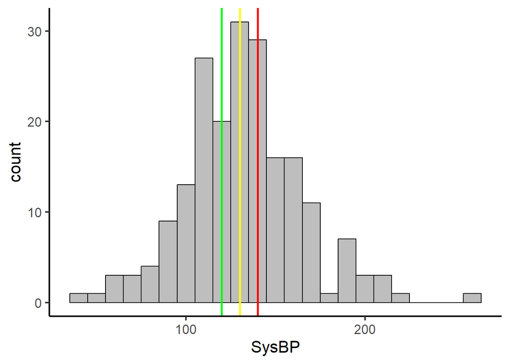

```r
ggplot(data = ICU,
        aes(x = SysBP)) +
  geom_histogram(binwidth = 10, color = "black", fill = "grey") +
  geom_vline(xintercept = 120, color = "green", linewidth = 1) +
  geom_vline(xintercept = 130, color = "yellow", linewidth = 1) +
  geom_vline(xintercept = 140, color = "red", linewidth = 1)
```

2. Make dotplots of blood pressure for emergency vs elective admission patients. Try different numbers of bins or binwidths.

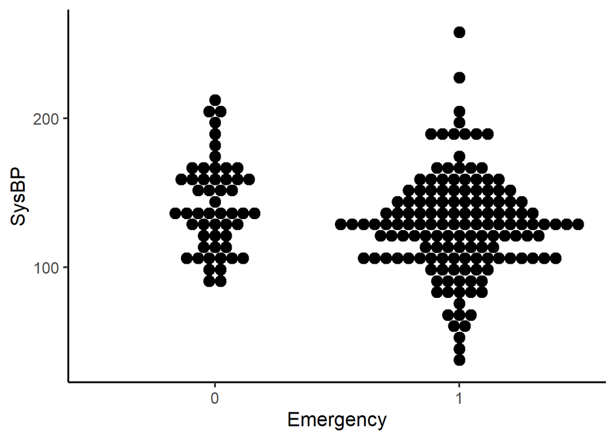

```r
ggplot(data = ICU,
       aes(x = Emergency, y = SysBP)) +
  geom_dotplot(method = "histodot",
               binaxis = "y",
               stackdir = "center")
```

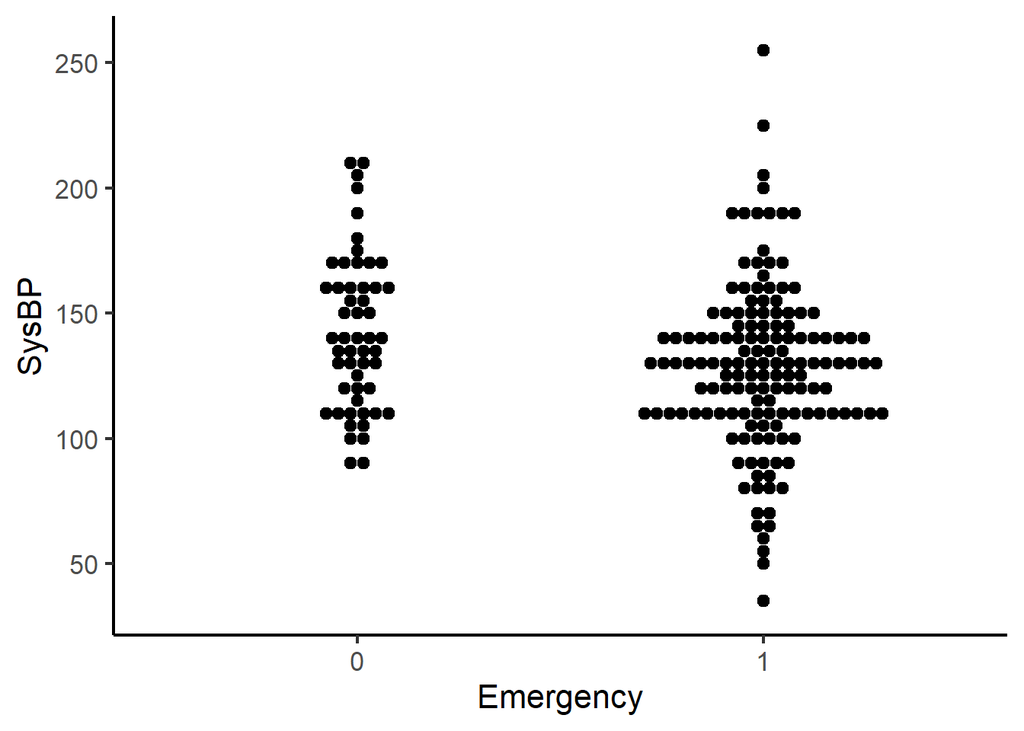

```r
ggplot(data = ICU,
       aes(x = Emergency, y = SysBP)) +
  geom_dotplot(binwidth = 5,
               method = "histodot",
               binaxis = "y",
               stackdir = "center")
```

3. Make a scatterplot of blood pressure (Y) vs age (X). Add a straight line to the plot. Does it look like blood pressure increases, decreases, or is relatively stable over ages?

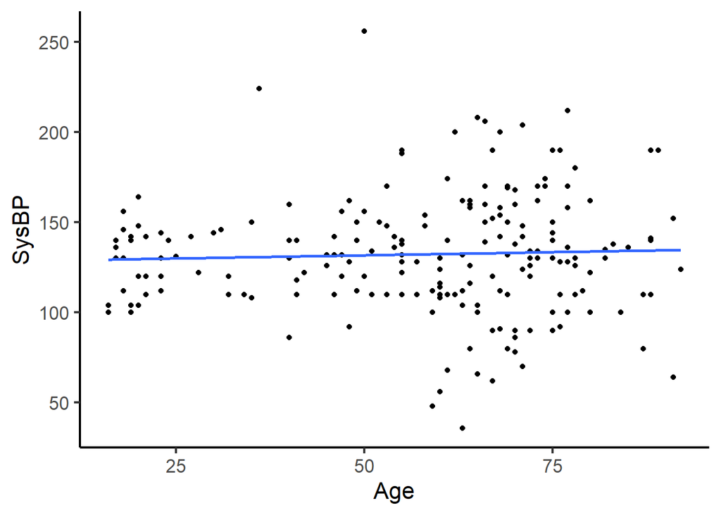

```r
ggplot(data = ICU,
       aes(x = Age, y = SysBP)) +
  geom_point() +
  geom_smooth(method = "lm", se = FALSE)
```

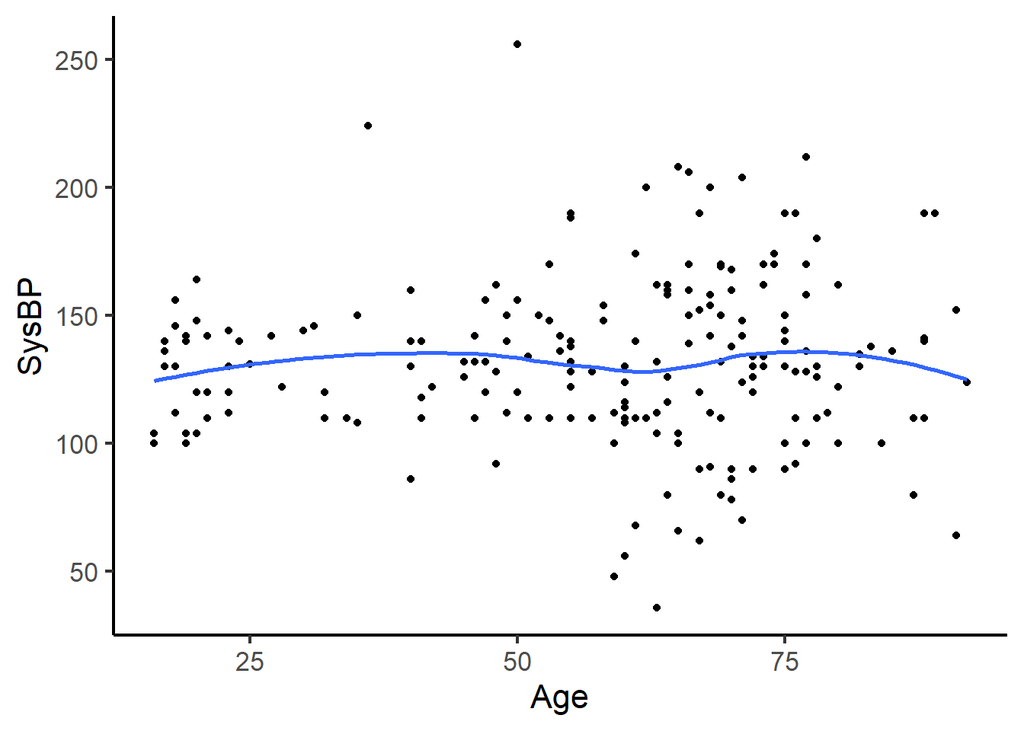

```r
ggplot(data = ICU,
       aes(x = Age, y = SysBP)) +
  geom_point() +
  geom_smooth(se = FALSE)
```